Liam McShane

# Predicting Volatile Acidity in wine using other chemical measurements

## Introduction

The objective of this project is to predict the level of Volatile Acidity in a wine using other independent chemical properties of the wine using the Wine Quality datasets from the UCI Machine Learning Repository: https://archive.ics.uci.edu/ml/machine-learning-databases/wine-quality/ (Cortez et al., 2009).

## Overview

### Project Aim

The aim of this project is to apply multiple linear regression to try and predict the level of Volatile Acidity in a wine based off of other independent variables of the same wine.

### Target Feature

The datasets contain 10 independent measurements, and one categorical variable (wine rating), and one target variable. The target variable in this case is the Volatile Acidity level of the wine. Volatile Acidity "is a measure of the low molecular weight, or steam-distillable, fatty acids in wine, with by far the major acid being acetic acid (>93%)".

Volatile Acidity (VA) is a byproduct of long fermentation times and oxygen exposure during winemaking. Typically considered a fault above certain levels, VA in small amounts can add red fruit aromas to wines, and starts to smell like vinegar and nail-polish remover in higher concentrations. Recently, minimal-intervention wine techniques have started to become very trendy in the wine world, with wine made in the style often referred to as "natural wine", and some wine makers have switched to more rustic production methods including abandoning exogenous sulfur additions and using wild yeasts instead of controlled yeast additions for fermentation. Criticisms of "natural wine" typically mention high levels of VA as the main fault with these wines. As such, it will be interesting to explore whether sulfur dioxide levels are inversely correlated with VA.

### Desriptive Features

The variables are as follows (from winequality.names file) 1 - fixed acidity (continuous, measure of non-volatile acids in wine, inc. tartaric acid, malic acid, lactic acid) 2 - volatile acidity (continuous, measure of volatile acids in wine, mostly acetic acid) 3 - citric acid (continuous) 4 - residual sugar (continuous, measure of unfermented sugars from grapes) 5 - chlorides (continuous) 6 - free sulfur dioxide (continuous, measure of SO2 in its free form in wine) 7 - total sulfur dioxide (continuous, total overall sulfur) 8 - density (continuous, density of wine) 9 - pH (continuous) 10 - sulphates (continuous) 11 - alcohol (continuous, as a percentage of the wine) 12 - quality (discrete, subjective rating of wine by wine critics)

## Data Preparation

The data in this case is not very difficult to prepare. We will combine the csv files for both red and white wine together, giving them their own value for red and white wine as another column in the combined data frame.

```python
# Importing modules
import numpy as np
import pandas as pd
import matplotlib.pyplot as plt
import seaborn as sns
import statsmodels.api as sm
import statsmodels.formula.api as smf
import patsy
import warnings
###
warnings.filterwarnings('ignore')
###
%matplotlib inline
%config InlineBackend.figure_format = 'retina'
plt.style.use("ggplot")
```

```python
# Read in data

attribNames = [
    'fixed_acidity',
    'volatile_acidity',
    'citric_acid',
    'residual_sugar',
    'chlorides',
    'free_sulfur_dioxide',
    'total_sulfur_dioxide',
    'density',
    'ph',
    'sulphates',
    'alcohol',
    'quality',
]
url = (
    "https://archive.ics.uci.edu/ml/machine-learning-databases/wine-quality/winequality-white.csv",
    "https://archive.ics.uci.edu/ml/machine-learning-databases/wine-quality/winequality-red.csv",
)
red_data = pd.read_csv(url[0], sep = ';', skiprows=1, names = attribNames, header = None)
white_data = pd.read_csv(url[1], sep = ';', skiprows=1, names = attribNames, header = None)

# Add 'Red' and 'White' attribute to respective data sets
column_length = len(red_data['ph'])
red_data['wine_type'] = pd.Series(np.random.randn(column_length), index=red_data.index)
red_data.loc[:,'wine_type'] = 'red'

column_length = len(white_data['ph'])
white_data['wine_type'] = pd.Series(np.random.randn(column_length), index=white_data.index)
white_data.loc[:,'wine_type'] = 'white'


# Join data sets together
data = pd.concat([red_data, white_data])

# Display random 10 rows
data.sample(10, random_state=999)
```

|  | fixed_acidity | volatile_acidity | citric_acid | residual_sugar | chlorides | free_sulfur_dioxide | total_sulfur_dioxide | density | ph | sulphates | alcohol | quality | wine_type |
| --- | --- | --- | --- | --- | --- | --- | --- | --- | --- | --- | --- | --- | --- |
| 1188 | 6.7 | 0.64 | 0.23 | 2.10 | 0.080 | 11.0 | 119.0 | 0.99538 | 3.36 | 0.70 | 10.9 | 5 | white |
| 299 | 6.9 | 0.67 | 0.06 | 2.10 | 0.080 | 8.0 | 33.0 | 0.99845 | 3.68 | 0.71 | 9.6 | 5 | white |
| 1311 | 6.3 | 0.23 | 0.22 | 3.75 | 0.039 | 37.0 | 116.0 | 0.99270 | 3.23 | 0.50 | 10.7 | 6 | red |
| 1462 | 6.8 | 0.64 | 0.03 | 2.30 | 0.075 | 14.0 | 31.0 | 0.99545 | 3.36 | 0.58 | 10.4 | 6 | white |
| 717 | 7.6 | 0.46 | 0.11 | 2.60 | 0.079 | 12.0 | 49.0 | 0.99680 | 3.21 | 0.57 | 10.0 | 5 | white |
| 139 | 8.1 | 0.28 | 0.39 | 1.90 | 0.029 | 18.0 | 79.0 | 0.99230 | 3.23 | 0.52 | 11.8 | 6 | red |
| 1554 | 7.9 | 0.42 | 0.49 | 8.20 | 0.056 | 32.0 | 164.0 | 0.99650 | 3.29 | 0.60 | 11.2 | 7 | red |
| 3416 | 7.2 | 0.37 | 0.40 | 11.60 | 0.032 | 34.0 | 214.0 | 0.99630 | 3.10 | 0.51 | 9.8 | 6 | red |
| 1064 | 8.1 | 0.26 | 0.37 | 1.90 | 0.072 | 48.0 | 159.0 | 0.99490 | 3.37 | 0.70 | 10.9 | 6 | red |
| 1856 | 10.0 | 0.91 | 0.42 | 1.60 | 0.056 | 34.0 | 181.0 | 0.99680 | 3.11 | 0.46 | 10.0 | 4 | red |

```python
# Check data types
print(data.dtypes)
```

```
fixed_acidity           float64
volatile_acidity        float64
citric_acid             float64
residual_sugar          float64
chlorides               float64
free_sulfur_dioxide     float64
total_sulfur_dioxide    float64
density                 float64
ph                      float64
sulphates               float64
alcohol                 float64
quality                   int64
wine_type                object
dtype: object
```

```python
# Print rows x cols
print(data.shape)

# Check for missing values in data set
print(data.isnull().sum())
```

```
(6497, 13)
fixed_acidity           0
volatile_acidity        0
citric_acid             0
residual_sugar          0
chlorides               0
free_sulfur_dioxide     0
total_sulfur_dioxide    0
density                 0
ph                      0
sulphates               0
alcohol                 0
quality                 0
wine_type               0
dtype: int64
```

```python
# Convert all cols+rows into floats if they only contain numeric strings
data.apply(pd.to_numeric, errors='ignore')
```

|  | fixed_acidity | volatile_acidity | citric_acid | residual_sugar | chlorides | free_sulfur_dioxide | total_sulfur_dioxide | density | ph | sulphates | alcohol | quality | wine_type |
| --- | --- | --- | --- | --- | --- | --- | --- | --- | --- | --- | --- | --- | --- |
| 0 | 7.0 | 0.270 | 0.36 | 20.7 | 0.045 | 45.0 | 170.0 | 1.00100 | 3.00 | 0.45 | 8.8 | 6 | red |
| 1 | 6.3 | 0.300 | 0.34 | 1.6 | 0.049 | 14.0 | 132.0 | 0.99400 | 3.30 | 0.49 | 9.5 | 6 | red |
| 2 | 8.1 | 0.280 | 0.40 | 6.9 | 0.050 | 30.0 | 97.0 | 0.99510 | 3.26 | 0.44 | 10.1 | 6 | red |
| 3 | 7.2 | 0.230 | 0.32 | 8.5 | 0.058 | 47.0 | 186.0 | 0.99560 | 3.19 | 0.40 | 9.9 | 6 | red |
| 4 | 7.2 | 0.230 | 0.32 | 8.5 | 0.058 | 47.0 | 186.0 | 0.99560 | 3.19 | 0.40 | 9.9 | 6 | red |
| ... | ... | ... | ... | ... | ... | ... | ... | ... | ... | ... | ... | ... | ... |
| 1594 | 6.2 | 0.600 | 0.08 | 2.0 | 0.090 | 32.0 | 44.0 | 0.99490 | 3.45 | 0.58 | 10.5 | 5 | white |
| 1595 | 5.9 | 0.550 | 0.10 | 2.2 | 0.062 | 39.0 | 51.0 | 0.99512 | 3.52 | 0.76 | 11.2 | 6 | white |
| 1596 | 6.3 | 0.510 | 0.13 | 2.3 | 0.076 | 29.0 | 40.0 | 0.99574 | 3.42 | 0.75 | 11.0 | 6 | white |
| 1597 | 5.9 | 0.645 | 0.12 | 2.0 | 0.075 | 32.0 | 44.0 | 0.99547 | 3.57 | 0.71 | 10.2 | 5 | white |
| 1598 | 6.0 | 0.310 | 0.47 | 3.6 | 0.067 | 18.0 | 42.0 | 0.99549 | 3.39 | 0.66 | 11.0 | 6 | white |

6497 rows × 13 columns

## Data Exploration

### Uninvariate visualisation

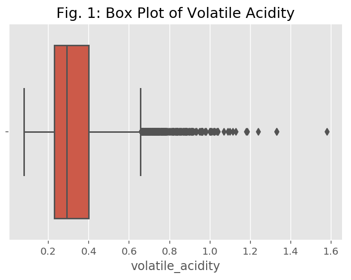

```python
#Boxplot
sns.boxplot(data['volatile_acidity']).set_title('Fig. 1: Box Plot of Volatile Acidity')
plt.show();
```

[output not shown]

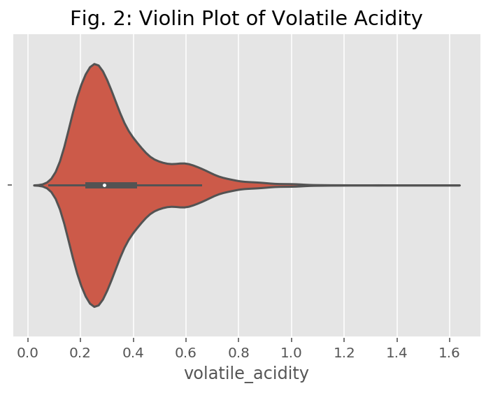

```python
#Violin plot
sns.violinplot(data['volatile_acidity']).set_title('Fig. 2: Violin Plot of Volatile Acidity')
```

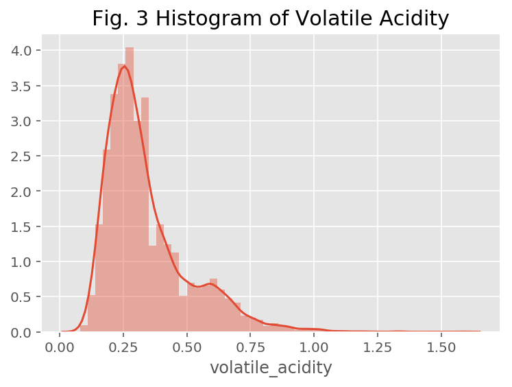

```python
#Histogram
sns.distplot(data['volatile_acidity'], kde = True).set_title('Fig. 3 Histogram of Volatile Acidity', fontsize = 15)
plt.show();
```

### Multivariate Visualisation

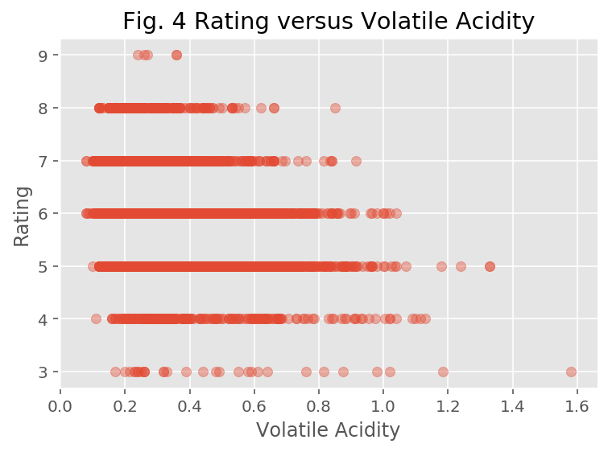

```python
va = data['volatile_acidity']

plt.scatter(va, data['quality'], alpha = 0.4)
plt.title('Fig. 4 Rating versus Volatile Acidity')
plt.xlabel('Volatile Acidity')
plt.ylabel('Rating')
plt.show();
```

We can see that wines with higher levels of volatile acidity don't attract high ratings from wine critics

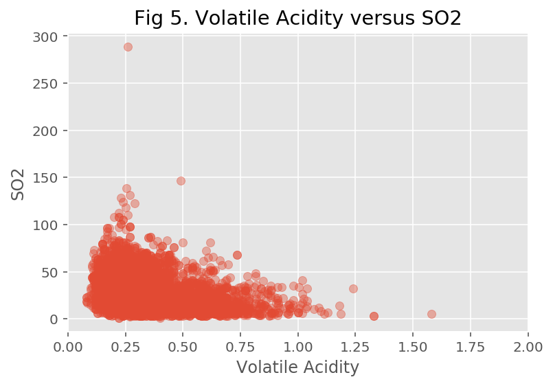

```python
va = data['volatile_acidity']

plt.scatter(va, data['free_sulfur_dioxide'], alpha = 0.4)
plt.title('Fig 5. Volatile Acidity versus SO2')
plt.xlim(0,2)
plt.xlabel('Volatile Acidity')
plt.ylabel('SO2')
plt.show();
```

We observe that at higher levels of sulfur additions, wines tend towards lower volatile acidity, and vice versa

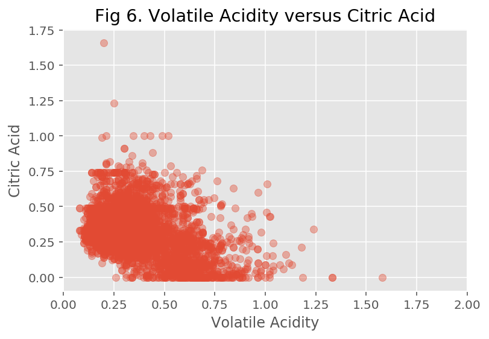

```python
va = data['volatile_acidity']

plt.scatter(va, data['citric_acid'], alpha = 0.4)
plt.title('Fig 6. Volatile Acidity versus Citric Acid')
plt.xlim(0,2)
plt.xlabel('Volatile Acidity')
plt.ylabel('Citric Acid')
plt.show();
```

Curiously we observe an slight inverse relationship between Citric Acid and Volatile Acidity. Citric acid is sometimes added to wine to artificially increase acidity. Could this be because higher intervention winemaking is more likely to control Volatile Acidity?

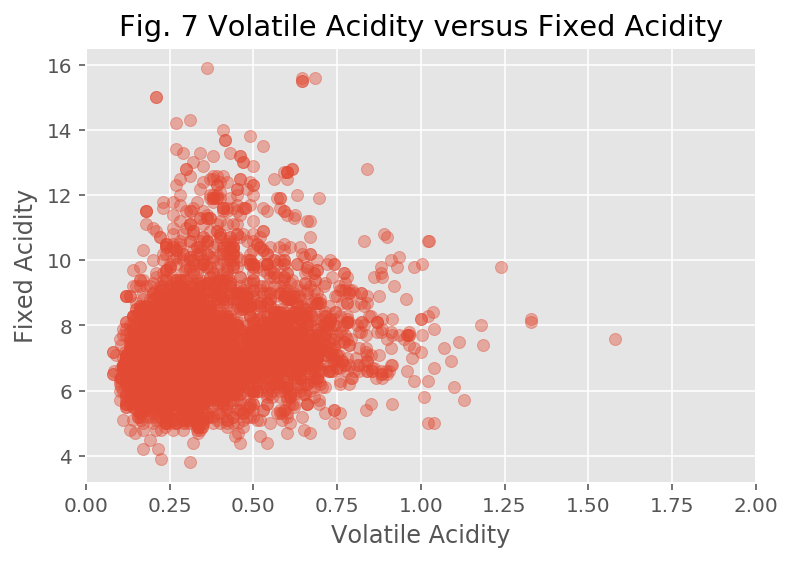

```python
va = data['volatile_acidity']

plt.scatter(va, data['fixed_acidity'], alpha = 0.4)
plt.title('Fig. 7 Volatile Acidity versus Fixed Acidity')
plt.xlim(0,2)
plt.xlabel('Volatile Acidity')
plt.ylabel('Fixed Acidity')
plt.show();
```

We don't see a significant relationship between VA and fixed acidity

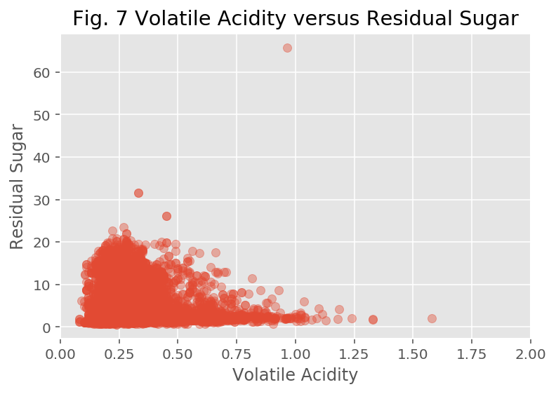

```python
va = data['volatile_acidity']

plt.scatter(va, data['residual_sugar'], alpha = 0.4)
plt.title('Fig. 7 Volatile Acidity versus Residual Sugar')
plt.xlim(0,2)
plt.xlabel('Volatile Acidity')
plt.ylabel('Residual Sugar')
plt.show();
```

We can see that wines high in VA tend to have low residual sugar, and vice versa.

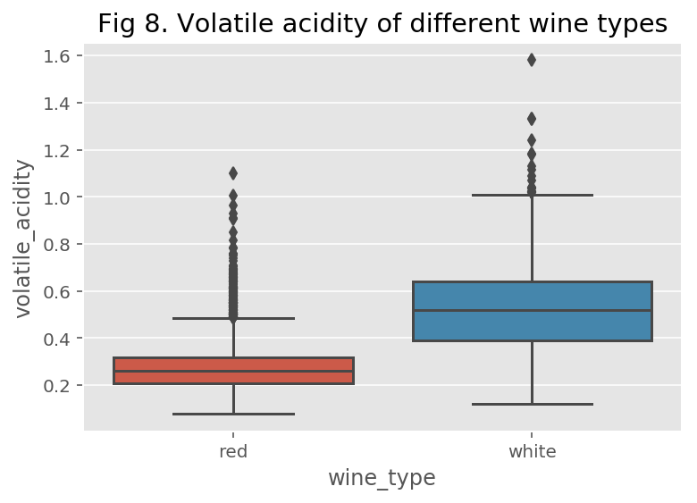

```python
sns.boxplot(data['wine_type'], data['volatile_acidity']);
plt.title('Fig 8. Volatile acidity of different wine types')
plt.show();
```

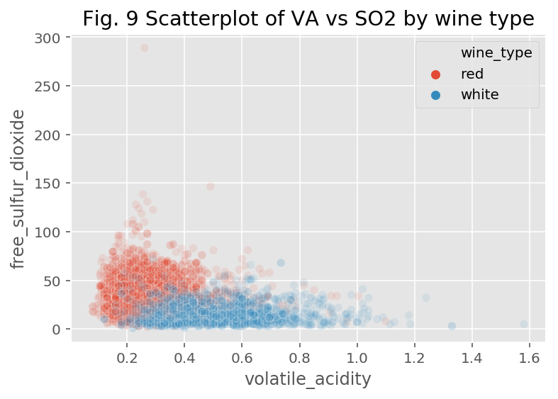

```python
va = data['volatile_acidity']
fsd = data['free_sulfur_dioxide']
sns.scatterplot(va, fsd, hue = data['wine_type'], alpha = 0.1)
plt.title('Fig. 9 Scatterplot of VA vs SO2 by wine type');
plt.legend(loc = 'upper right')
plt.show();
```

We observe that red wine has a greater variance in free sulfur levels than white wine.

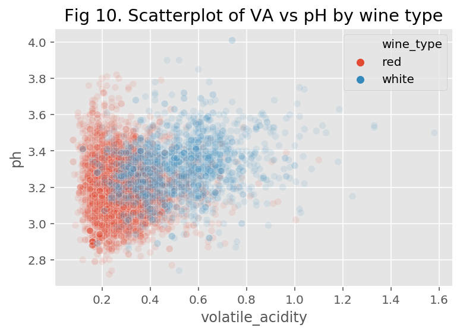

```python
va = data['volatile_acidity']
ph = data['ph']
sns.scatterplot(va, ph, hue = data['wine_type'], alpha = 0.1)
plt.title('Fig 10. Scatterplot of VA vs pH by wine type');
plt.legend(loc = 'upper right')
plt.show();
```

## Statistical Modeling and Performance Evaluation

### Full Model

We fit a multiple linear regression that predicts 'volatile-acidity' using all of the available features except 'quality'. Quality rating is subjective, likely predicts our target variable, and we don't want it skewing our results.

```python
# formula string for statsmodels module
formula_string_indep_vars = ' + '.join(data.drop(columns=['volatile_acidity', 'quality']).columns)
formula_string = 'volatile acidity ~ ' + formula_string_indep_vars
print('formula_string: ', formula_string)
```

```
formula_string:  volatile acidity ~ fixed_acidity + citric_acid + residual_sugar + chlorides + free_sulfur_dioxide + total_sulfur_dioxide + density + ph + sulphates + alcohol + wine_type
```

```python
# one-hot encoding of wine_type values
data_encoded = pd.get_dummies(data, drop_first=True)
# Display random 10 rows
data_encoded.sample(10, random_state=999)
```

|  | fixed_acidity | volatile_acidity | citric_acid | residual_sugar | chlorides | free_sulfur_dioxide | total_sulfur_dioxide | density | ph | sulphates | alcohol | quality | wine_type_white |
| --- | --- | --- | --- | --- | --- | --- | --- | --- | --- | --- | --- | --- | --- |
| 1188 | 6.7 | 0.64 | 0.23 | 2.10 | 0.080 | 11.0 | 119.0 | 0.99538 | 3.36 | 0.70 | 10.9 | 5 | 1 |
| 299 | 6.9 | 0.67 | 0.06 | 2.10 | 0.080 | 8.0 | 33.0 | 0.99845 | 3.68 | 0.71 | 9.6 | 5 | 1 |
| 1311 | 6.3 | 0.23 | 0.22 | 3.75 | 0.039 | 37.0 | 116.0 | 0.99270 | 3.23 | 0.50 | 10.7 | 6 | 0 |
| 1462 | 6.8 | 0.64 | 0.03 | 2.30 | 0.075 | 14.0 | 31.0 | 0.99545 | 3.36 | 0.58 | 10.4 | 6 | 1 |
| 717 | 7.6 | 0.46 | 0.11 | 2.60 | 0.079 | 12.0 | 49.0 | 0.99680 | 3.21 | 0.57 | 10.0 | 5 | 1 |
| 139 | 8.1 | 0.28 | 0.39 | 1.90 | 0.029 | 18.0 | 79.0 | 0.99230 | 3.23 | 0.52 | 11.8 | 6 | 0 |
| 1554 | 7.9 | 0.42 | 0.49 | 8.20 | 0.056 | 32.0 | 164.0 | 0.99650 | 3.29 | 0.60 | 11.2 | 7 | 0 |
| 3416 | 7.2 | 0.37 | 0.40 | 11.60 | 0.032 | 34.0 | 214.0 | 0.99630 | 3.10 | 0.51 | 9.8 | 6 | 0 |
| 1064 | 8.1 | 0.26 | 0.37 | 1.90 | 0.072 | 48.0 | 159.0 | 0.99490 | 3.37 | 0.70 | 10.9 | 6 | 0 |
| 1856 | 10.0 | 0.91 | 0.42 | 1.60 | 0.056 | 34.0 | 181.0 | 0.99680 | 3.11 | 0.46 | 10.0 | 4 | 0 |

```python
formula_string_indep_vars_encoded = ' + '.join(data_encoded.drop(columns=['volatile_acidity', 'quality']).columns)
formula_string_encoded = 'volatile_acidity ~ ' + formula_string_indep_vars_encoded
print('formula_string_encoded: ', formula_string_encoded)
```

```
formula_string_encoded:  volatile_acidity ~ fixed_acidity + citric_acid + residual_sugar + chlorides + free_sulfur_dioxide + total_sulfur_dioxide + density + ph + sulphates + alcohol + wine_type_white
```

```python
formula_string_encoded = formula_string_encoded + ' + residual_sugar:free_sulfur_dioxide + citric_acid:fixed_acidity + residual_sugar:citric_acid + free_sulfur_dioxide:fixed_acidity + free_sulfur_dioxide:citric_acid + total_sulfur_dioxide:citric_acid'
print('formula_string_encoded: ', formula_string_encoded)
```

[output not shown]

Due to the curious relationship of residual sugar and VA, citric acid and VA, and sulfur dioxide and VA, we add the interaction terms of citric acid and sulfur dioxide and residual sugar.

```python
model_full = sm.formula.ols(formula=formula_string_encoded, data=data_encoded)
###
model_full_fitted = model_full.fit()
###
print(model_full_fitted.summary())
```

```
                            OLS Regression Results
==============================================================================
Dep. Variable:       volatile_acidity   R-squared:                       0.584
Model:                            OLS   Adj. R-squared:                  0.582
Method:                 Least Squares   F-statistic:                     534.0
Date:                Sun, 10 Nov 2019   Prob (F-statistic):               0.00
Time:                        22:50:06   Log-Likelihood:                 5348.0
No. Observations:                6497   AIC:                        -1.066e+04
Df Residuals:                    6479   BIC:                        -1.054e+04
Df Model:                          17
Covariance Type:            nonrobust
======================================================================================================
                                         coef    std err          t      P>|t|      [0.025      0.975]
------------------------------------------------------------------------------------------------------
Intercept                            -15.5760      2.064     -7.546      0.000     -19.622     -11.530
fixed_acidity                         -0.0023      0.004     -0.553      0.580      -0.011       0.006
citric_acid                           -0.9754      0.059    -16.622      0.000      -1.090      -0.860
residual_sugar                        -0.0103      0.001     -7.661      0.000      -0.013      -0.008
chlorides                              0.7287      0.049     14.999      0.000       0.634       0.824
free_sulfur_dioxide                    0.0001      0.001      0.185      0.853      -0.001       0.001
total_sulfur_dioxide                  -0.0002   9.54e-05     -2.498      0.013      -0.000   -5.13e-05
density                               16.1354      2.097      7.693      0.000      12.024      20.247
ph                                    -0.0698      0.013     -5.283      0.000      -0.096      -0.044
sulphates                             -0.1197      0.011    -10.883      0.000      -0.141      -0.098
alcohol                                0.0314      0.003     11.868      0.000       0.026       0.037
wine_type_white                        0.1879      0.008     23.429      0.000       0.172       0.204
residual_sugar:free_sulfur_dioxide  -3.51e-06   1.81e-05     -0.194      0.846   -3.89e-05    3.19e-05
citric_acid:fixed_acidity              0.0226      0.007      3.313      0.001       0.009       0.036
residual_sugar:citric_acid             0.0165      0.002      7.078      0.000       0.012       0.021
free_sulfur_dioxide:fixed_acidity     -0.0003   7.45e-05     -4.566      0.000      -0.000      -0.000
free_sulfur_dioxide:citric_acid        0.0025      0.001      2.992      0.003       0.001       0.004
total_sulfur_dioxide:citric_acid       0.0029      0.000     11.449      0.000       0.002       0.003
==============================================================================
Omnibus:                     1705.759   Durbin-Watson:                   1.690
Prob(Omnibus):                  0.000   Jarque-Bera (JB):             6978.367
Skew:                           1.241   Prob(JB):                         0.00
Kurtosis:                       7.429   Cond. No.                     8.95e+05
==============================================================================

Warnings:
[1] Standard Errors assume that the covariance matrix of the errors is correctly specified.
[2] The condition number is large, 8.95e+05. This might indicate that there are
strong multicollinearity or other numerical problems.
```

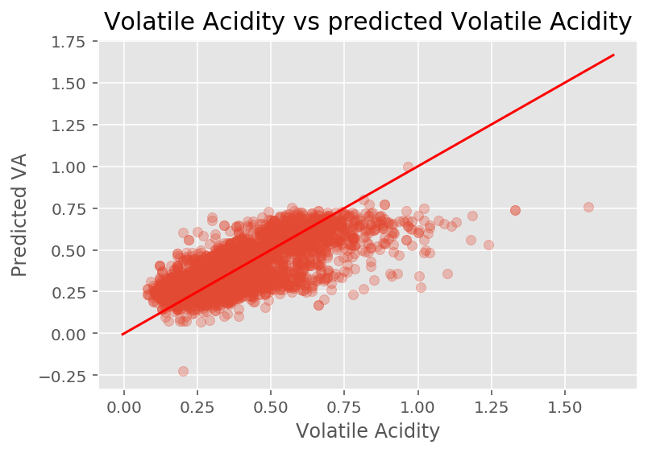

```python
def plot_line(axis, slope, intercept, **kargs):
    xmin, xmax = axis.get_xlim()
    plt.plot([xmin, xmax], [xmin*slope+intercept, xmax*slope+intercept], **kargs)

# Creating scatter plot
plt.scatter(data_encoded['volatile_acidity'], model_full_fitted.fittedvalues, alpha=0.3);
plot_line(axis=plt.gca(), slope=1, intercept=0, c="red");
plt.xlabel('Volatile Acidity');
plt.ylabel('Predicted VA');
plt.title('Volatile Acidity vs predicted Volatile Acidity', fontsize=15);
plt.show();
```

### Residuals

We check the residual graphs to make sure that the data is stochastically distributed

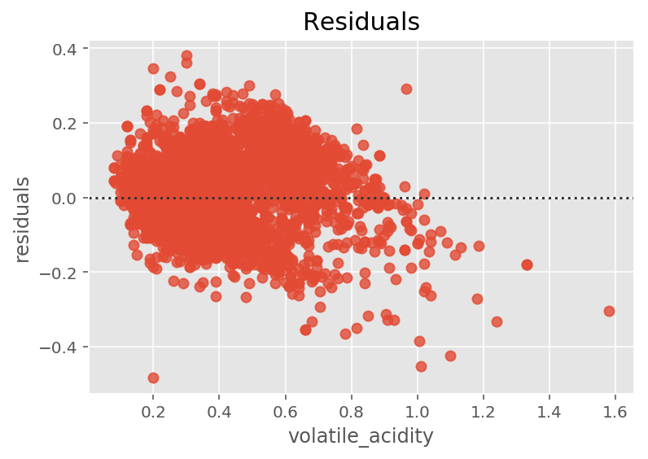

```python
sns.residplot(x=data_encoded['volatile_acidity'], y=model_full_fitted.fittedvalues);
plt.ylabel('residuals')
plt.title('Residuals', fontsize=15)
plt.show();
```

The graph looks good up until higher levels of VA, lets check a histogram for further analysis

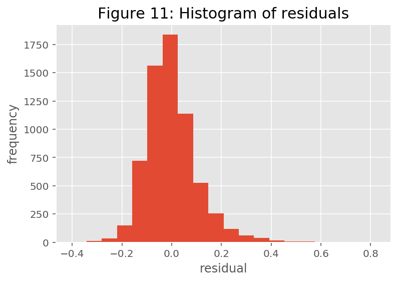

```python
residuals = data_encoded['volatile_acidity'] - model_full_fitted.fittedvalues
plt.hist(residuals, bins = 20);
plt.xlabel('residual');
plt.ylabel('frequency');
plt.title('Figure 11: Histogram of residuals', fontsize=15);
plt.show();
```

The graph is somewhat symmetrical around zero, meaning residuals are at least somewhat normally distributed.

### Backwards feature selection

Note that this backwards feature selection code was written by Dr Vural Aksakalli of RMIT University

```python
## create the patsy model description from formula
patsy_description = patsy.ModelDesc.from_formula(formula_string_encoded)

# initialize feature-selected fit to full model
linreg_fit = model_full_fitted

# do backwards elimination using p-values
p_val_cutoff = 0.05

## WARNING 1: The code below assumes that the Intercept term is present in the model.
## WARNING 2: It will work only with main effects and two-way interactions, if any.

print('\nPerforming backwards feature selection using p-values:')

while True:

    # uncomment the line below if you would like to see the regression summary
    # in each step:
    ### print(linreg_fit.summary())

    pval_series = linreg_fit.pvalues.drop(labels='Intercept')
    pval_series = pval_series.sort_values(ascending=False)
    term = pval_series.index[0]
    pval = pval_series[0]
    if (pval < p_val_cutoff):
        break
    term_components = term.split(':')
    print(f'\nRemoving term "{term}" with p-value {pval:.4}')
    if (len(term_components) == 1): ## this is a main effect term
        patsy_description.rhs_termlist.remove(patsy.Term([patsy.EvalFactor(term_components[0])]))
    else: ## this is an interaction term
        patsy_description.rhs_termlist.remove(patsy.Term([patsy.EvalFactor(term_components[0]),
                                                        patsy.EvalFactor(term_components[1])]))

    linreg_fit = smf.ols(formula=patsy_description, data=data_encoded).fit()

###
## this is the clean fit after backwards elimination
model_reduced_fitted = smf.ols(formula = patsy_description, data = data_encoded).fit()
###

#########
print("\n***")
print(model_reduced_fitted.summary())
print("***")
print(f"Regression number of terms: {len(model_reduced_fitted.model.exog_names)}")
print(f"Regression F-distribution p-value: {model_reduced_fitted.f_pvalue:.4f}")
print(f"Regression R-squared: {model_reduced_fitted.rsquared:.4f}")
print(f"Regression Adjusted R-squared: {model_reduced_fitted.rsquared_adj:.4f}")
```

```
Performing backwards feature selection using p-values:

Removing term "free_sulfur_dioxide" with p-value 0.8532

Removing term "residual_sugar:free_sulfur_dioxide" with p-value 0.8612

Removing term "fixed_acidity" with p-value 0.4677

***
                            OLS Regression Results
==============================================================================
Dep. Variable:       volatile_acidity   R-squared:                       0.584
Model:                            OLS   Adj. R-squared:                  0.583
Method:                 Least Squares   F-statistic:                     648.7
Date:                Sun, 10 Nov 2019   Prob (F-statistic):               0.00
Time:                        22:50:07   Log-Likelihood:                 5347.7
No. Observations:                6497   AIC:                        -1.067e+04
Df Residuals:                    6482   BIC:                        -1.056e+04
Df Model:                          14
Covariance Type:            nonrobust
=====================================================================================================
                                        coef    std err          t      P>|t|      [0.025      0.975]
-----------------------------------------------------------------------------------------------------
Intercept                           -14.9363      1.828     -8.170      0.000     -18.520     -11.353
citric_acid                          -0.9513      0.048    -19.856      0.000      -1.045      -0.857
residual_sugar                       -0.0102      0.001     -9.537      0.000      -0.012      -0.008
chlorides                             0.7325      0.048     15.186      0.000       0.638       0.827
total_sulfur_dioxide                 -0.0002   8.65e-05     -2.479      0.013      -0.000   -4.49e-05
density                              15.4649      1.841      8.402      0.000      11.857      19.073
ph                                   -0.0651      0.011     -5.711      0.000      -0.087      -0.043
sulphates                            -0.1190      0.011    -10.900      0.000      -0.140      -0.098
alcohol                               0.0308      0.002     12.486      0.000       0.026       0.036
wine_type_white                       0.1885      0.008     23.942      0.000       0.173       0.204
citric_acid:fixed_acidity             0.0192      0.005      4.135      0.000       0.010       0.028
residual_sugar:citric_acid            0.0167      0.002      7.223      0.000       0.012       0.021
free_sulfur_dioxide:fixed_acidity    -0.0003   3.69e-05     -9.171      0.000      -0.000      -0.000
free_sulfur_dioxide:citric_acid       0.0026      0.001      3.555      0.000       0.001       0.004
total_sulfur_dioxide:citric_acid      0.0028      0.000     12.530      0.000       0.002       0.003
==============================================================================
Omnibus:                     1701.198   Durbin-Watson:                   1.689
Prob(Omnibus):                  0.000   Jarque-Bera (JB):             6925.874
Skew:                           1.239   Prob(JB):                         0.00
Kurtosis:                       7.410   Cond. No.                     5.47e+05
==============================================================================

Warnings:
[1] Standard Errors assume that the covariance matrix of the errors is correctly specified.
[2] The condition number is large, 5.47e+05. This might indicate that there are
strong multicollinearity or other numerical problems.
***
Regression number of terms: 15
Regression F-distribution p-value: 0.0000
Regression R-squared: 0.5835
Regression Adjusted R-squared: 0.5826
```

### Residuals

Lets check the residuals again

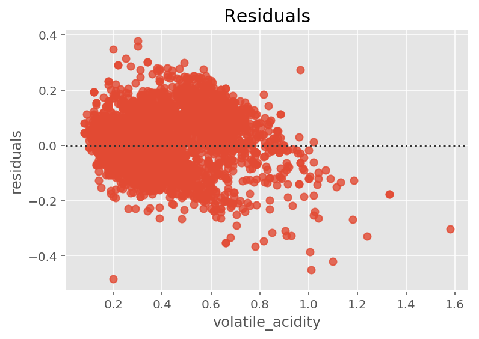

```python
sns.residplot(x=data_encoded['volatile_acidity'], y=model_reduced_fitted.fittedvalues);
plt.ylabel('residuals')
plt.title('Residuals', fontsize=15)
plt.show();
```

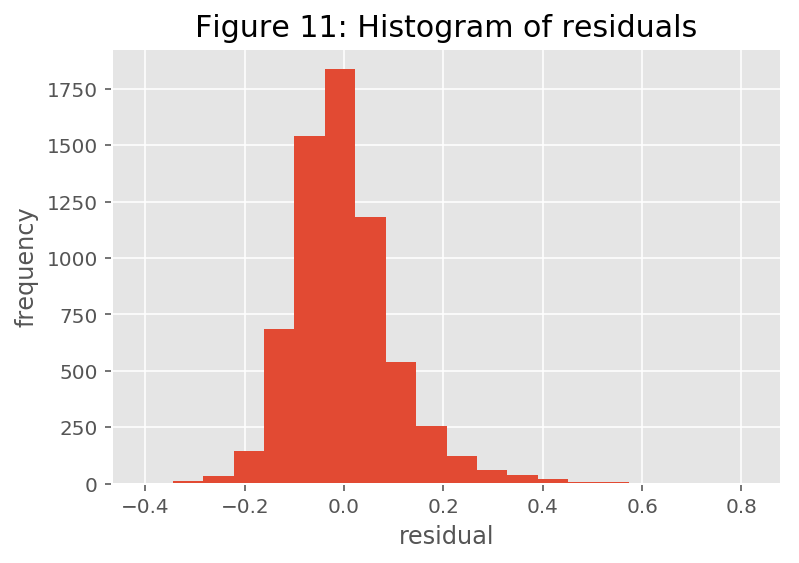

```python
residuals = data_encoded['volatile_acidity'] - model_reduced_fitted.fittedvalues
plt.hist(residuals, bins = 20);
plt.xlabel('residual');
plt.ylabel('frequency');
plt.title('Figure 11: Histogram of residuals', fontsize=15);
plt.show();
```

### Final plot of prediction versus actual

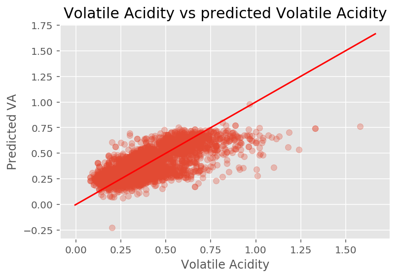

```python
# Final
plt.scatter(data_encoded['volatile_acidity'], model_reduced_fitted.fittedvalues, alpha=0.3);
plot_line(axis=plt.gca(), slope=1, intercept=0, c="red");
plt.xlabel('Volatile Acidity');
plt.ylabel('Predicted VA');
plt.title('Volatile Acidity vs predicted Volatile Acidity', fontsize=15);
plt.show();
```

## References

- P. Cortez, A. Cerdeira, F. Almeida, T. Matos and J. Reis. Modeling wine preferences by data mining from physicochemical properties. In Decision Support Systems, Elsevier, 47(4):547-553. ISSN: 0167-9236.  
  Dataset from: UCI Machine Learning Repository [online]. https://archive.ics.uci.edu/ml/machine-learning-databases/wine-quality/ [Accessed 2019-11-6]